# S670 Exploratory Data Analysis, Assignment2

- Author: Kimball Wu
- Discussed with: Sumeet Mishra, Ling Tan

# Data Cleaning

```r
library(ggplot2)
suppressWarnings(library(dplyr))
library(repr)
library(reshape2)
library(RColorBrewer)

# read
voter = read.csv('D:/docs/[IU lesson]/exploratory data analysis/assign2/anes_pilot_2016.csv')
```

```r
# clean data
clean = function(l){
  r = l
  r[r>100] = NA
  return(r)
}

candidates = c('fttrump','fthrc','ftsanders','ftrubio')
cols = c(candidates, 'immig_numb')

data = voter[,cols]
data[,candidates] = as.data.frame(lapply(data[,candidates], clean))
data = data[complete.cases(data),]
cnames = c('Trump','Clinton','Sanders','Rubio')
colnames(data) = c(cnames,'immig_numb')
```

# Graph 1

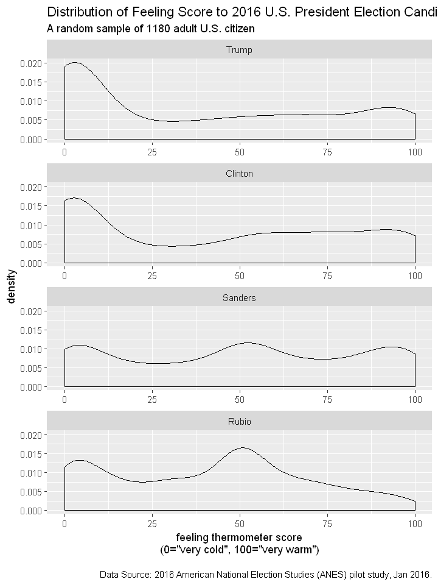

```r
# distribution approach
dist = melt(data[,cnames], value.name = 'score')
options(repr.plot.width=6, repr.plot.height=8)
ggplot(dist, aes(x=score))+
       geom_density()+
       facet_wrap( ~variable, ncol=1, scale='free_x')+
       labs(title = "Distribution of Feeling Score to 2016 U.S. President Election Candidates ",
            subtitle = sprintf('A random sample of %d adult U.S. citizen', dim(data)[[1]]),
            caption = "\nData Source: 2016 American National Election Studies (ANES) pilot study, Jan 2016.",
            x = 'feeling thermometer score\n(0="very cold", 100="very warm")')
```

## Discussion

The shape of feeling score distribution for the four candidates are very different.

Trump's and Clinton's distribution have similar right-skewed shape, which indicates many people really don't like them. And For the rest of the people, the attitude toward them are somewhat spread uniformly across the range of feeling score scale, except the right end ("very warm" end) is slightly thicker to the left ("cold" end).

The shape of Sanders' distribution can be described basically as a uniform distribution with some fluctuation. There are slightly more people who really like, really dislike, or indifference to Sunders than the people who feel somewhat like or somewhat dislike Sanders. In other way, you may say there are three insignificant peaks exist in the distribution of Sanders'.

Rubio's distribution has two significant peaks, locate at the attitude around "indifference"(around 50) and "very dislike"(around 0). There are few people who really like Rubio.

# Graph2

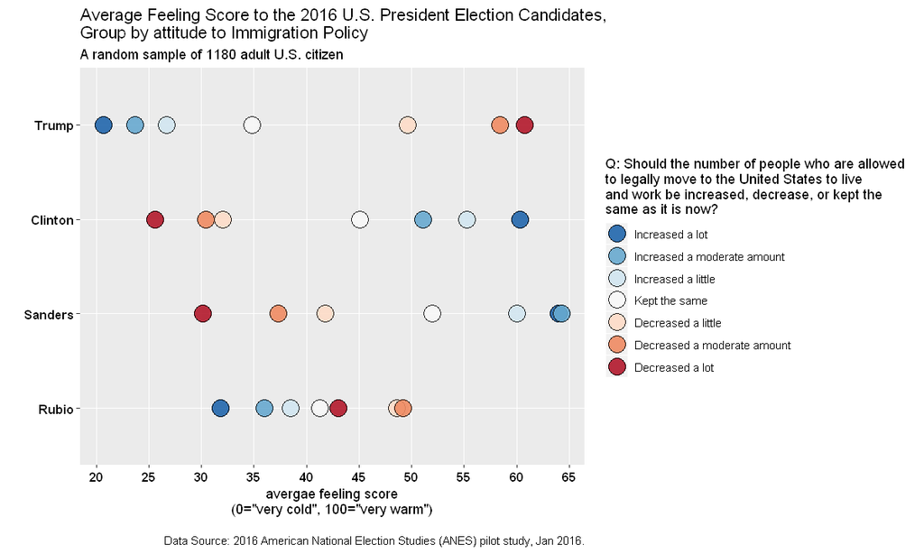

```r
# center approah
center = data[,c(cnames,'immig_numb')]
center = summarise(group_by(center, immig_numb),
                   Trump=mean(Trump), Clinton=mean(Clinton), Sanders=mean(Sanders), Rubio=mean(Rubio))

center = melt(center, id.vars = "immig_numb")
center[['immig_numb']] = as.character(center[['immig_numb']])
center[['variable']] = factor(center[['variable']], levels=rev(cnames))

options(repr.plot.width=10, repr.plot.height=6)
ggplot(center, aes(y=variable, x=value)) +
       geom_point(aes(fill=immig_numb), colour="black", shape=21, size=6, alpha=0.9)+
       scale_x_continuous(breaks=seq(15,70,5), minor_breaks=NULL, labels = as.character(seq(15,70,5)))+
       scale_fill_manual(values = rev(brewer.pal(7,'RdBu')),
                         name =paste0(c("Q: Should the number of people who are allowed",
                                        "to legally move to the United States to live",
                                        "and work be increased, decrease, or kept the",
                                        "same as it is now?"), collapse='\n'),
                         breaks = c('1','2','3','4','5','6','7'),
                         labels =c("Increased a lot",
                                   "Increased a moderate amount",
                                   "Increased a little",
                                   "Kept the same",
                                   "Decreased a little",
                                   "Decreased a moderate amount",
                                   "Decreased a lot"))+
       labs(title = "Average Feeling Score to the 2016 U.S. President Election Candidates,\nGroup by attitude to Immigration Policy",
            subtitle = sprintf('A random sample of %d adult U.S. citizen', dim(data)[[1]]),
            caption = "\nData Source: 2016 American National Election Studies (ANES) pilot study, Jan 2016.",
            y= '', x = 'avergae feeling score\n(0="very cold", 100="very warm")')+
       theme(axis.text.y=element_text(size=10, color='black', face='bold'),
             axis.text.x=element_text(size=10, color='black', face='bold'))
```

## Dissbusion

People's feeling to the candidates can be seperated by their attitude to immigration policy.